# Facebook Dataset Analysis Final Project

Jianye Han, Zach Litz, Megan Masanz

July 25, 2017

### Introduction

### Methods

#### Variable Exploration

##### 1. Variable Exploration Additive Model

Below is loading the packages used during the analysis

```r
library(MASS)
library(readr)
library(lmtest)
library(car)
library(knitr)
library(faraway)
fb = read.table("dataset_Facebook.csv", sep = ";", header = T)

#prepare categorical variables for use of dummy variables
fb$Type           = as.factor(fb$Type)
fb$Category       = as.factor(fb$Category)
fb$Post.Month     = as.factor(fb$Post.Month)
fb$Post.Hour      = as.factor(fb$Post.Hour)
fb$Post.Weekday   = as.factor(fb$Post.Weekday)
fb$Paid           = as.factor(fb$Paid)
```

Initial full additive model.

```r
full_model = lm(Lifetime.Post.Consumers ~ ., data = fb)
summary(full_model)
```

```
##
## Call:
## lm(formula = Lifetime.Post.Consumers ~ ., data = fb)
##
## Residuals:
##      Min       1Q   Median       3Q      Max
## -144.911  -11.227   -0.515   10.172  290.805
##
## Coefficients: (1 not defined because of singularities)
##                                                                       Estimate
## (Intercept)                                                          3.862e+01
## Page.total.likes                                                    -3.206e-04
## TypePhoto                                                           -1.190e+01
## TypeStatus                                                          -2.588e+01
## TypeVideo                                                            2.599e+01
## Category2                                                            5.754e+00
## Category3                                                            4.905e+00
## Post.Month2                                                          1.218e+01
## Post.Month3                                                          3.527e+00
## Post.Month4                                                          1.429e+01
## Post.Month5                                                          1.572e+01
## Post.Month6                                                          5.518e+00
## Post.Month7                                                          1.204e+01
## Post.Month8                                                          1.263e+01
## Post.Month9                                                          1.770e+01
## Post.Month10                                                         2.004e+01
## Post.Month11                                                        -5.190e-01
## Post.Month12                                                        -7.953e+00
## Post.Weekday2                                                        2.812e+00
## Post.Weekday3                                                        6.198e+00
## Post.Weekday4                                                        6.751e+00
## Post.Weekday5                                                       -1.710e+00
## Post.Weekday6                                                        5.496e-01
## Post.Weekday7                                                       -1.074e+00
## Post.Hour2                                                           1.259e+00
## Post.Hour3                                                          -1.822e+00
## Post.Hour4                                                           3.346e+00
## Post.Hour5                                                          -1.502e+01
## Post.Hour6                                                           1.178e+01
## Post.Hour7                                                          -7.351e+00
```

[output cut: 251 more lines]

```
## Lifetime.Post.Consumptions                                          ***
## Lifetime.Post.Impressions.by.people.who.have.liked.your.Page
## Lifetime.Post.reach.by.people.who.like.your.Page
## Lifetime.People.who.have.liked.your.Page.and.engaged.with.your.post ***
## comment                                                             ***
## like                                                                ***
## share                                                               ***
## Total.Interactions
## ---
## Signif. codes:  0 '***' 0.001 '**' 0.01 '*' 0.05 '.' 0.1 ' ' 1
##
## Residual standard error: 30.93 on 439 degrees of freedom
##   (5 observations deleted due to missingness)
## Multiple R-squared:  0.9989, Adjusted R-squared:  0.9988
## F-statistic:  7348 on 55 and 439 DF,  p-value: < 2.2e-16
```

```r
#Perfect correlation so removed
fb$Total.Interactions = NULL
full_model = lm(Lifetime.Post.Consumers ~ ., data = fb)
summary(full_model)
```

```
##
## Call:
## lm(formula = Lifetime.Post.Consumers ~ ., data = fb)
##
## Residuals:
##      Min       1Q   Median       3Q      Max
## -144.911  -11.227   -0.515   10.172  290.805
##
## Coefficients:
##                                                                       Estimate
## (Intercept)                                                          3.862e+01
## Page.total.likes                                                    -3.206e-04
## TypePhoto                                                           -1.190e+01
## TypeStatus                                                          -2.588e+01
## TypeVideo                                                            2.599e+01
## Category2                                                            5.754e+00
## Category3                                                            4.905e+00
## Post.Month2                                                          1.218e+01
## Post.Month3                                                          3.527e+00
## Post.Month4                                                          1.429e+01
## Post.Month5                                                          1.572e+01
## Post.Month6                                                          5.518e+00
## Post.Month7                                                          1.204e+01
## Post.Month8                                                          1.263e+01
## Post.Month9                                                          1.770e+01
## Post.Month10                                                         2.004e+01
## Post.Month11                                                        -5.190e-01
## Post.Month12                                                        -7.953e+00
## Post.Weekday2                                                        2.812e+00
## Post.Weekday3                                                        6.198e+00
## Post.Weekday4                                                        6.751e+00
## Post.Weekday5                                                       -1.710e+00
## Post.Weekday6                                                        5.496e-01
## Post.Weekday7                                                       -1.074e+00
## Post.Hour2                                                           1.259e+00
## Post.Hour3                                                          -1.822e+00
## Post.Hour4                                                           3.346e+00
## Post.Hour5                                                          -1.502e+01
## Post.Hour6                                                           1.178e+01
## Post.Hour7                                                          -7.351e+00
```

[output cut: 246 more lines]

```
## Lifetime.Engaged.Users                                              ***
## Lifetime.Post.Consumptions                                          ***
## Lifetime.Post.Impressions.by.people.who.have.liked.your.Page
## Lifetime.Post.reach.by.people.who.like.your.Page
## Lifetime.People.who.have.liked.your.Page.and.engaged.with.your.post ***
## comment                                                             ***
## like                                                                ***
## share                                                               ***
## ---
## Signif. codes:  0 '***' 0.001 '**' 0.01 '*' 0.05 '.' 0.1 ' ' 1
##
## Residual standard error: 30.93 on 439 degrees of freedom
##   (5 observations deleted due to missingness)
## Multiple R-squared:  0.9989, Adjusted R-squared:  0.9988
## F-statistic:  7348 on 55 and 439 DF,  p-value: < 2.2e-16
```

```r
levels(fb$Post.Weekday)
```

```
## [1] "1" "2" "3" "4" "5" "6" "7"
```

```r
levels(fb$Post.Hour)
```

```
##  [1] "1"  "2"  "3"  "4"  "5"  "6"  "7"  "8"  "9"  "10" "11" "12" "13" "14"
## [15] "15" "16" "17" "18" "19" "20" "22" "23"
```

```r
nrow(fb)
```

```
## [1] 500
```

```r
#Cleansing Data
fb = fb[complete.cases(fb), ]
nrow(fb)
```

```
## [1] 495
```

```r
length(coef(full_model))
```

```
## [1] 56
```

For initial analysis given the large number of variables, we will use a dataframe with generic names, being with an additive model analysis, add interactions, and determine the subset of variables we are interested in exploring, and at that point we will move back to using the actual predictor names using a subset of the fb dataset

```r
new_data = data.frame(
  y   = fb$Lifetime.Post.Consumers,
  x1  = fb$Page.total.likes,
  x2  = fb$Lifetime.Post.Total.Reach,
  x3  = fb$Lifetime.Post.Total.Impressions,
  x4  = fb$Lifetime.Engaged.Users,
  x5  = fb$Lifetime.Post.Consumptions,
  x6  = fb$Lifetime.Post.Impressions.by.people.who.have.liked.your.Page,
  x7  = fb$Lifetime.Post.reach.by.people.who.like.your.Page,
  x8  = fb$Lifetime.People.who.have.liked.your.Page.and.engaged.with.your.post,
  x9  = fb$comment,
  x10 = fb$like,
  x11 = fb$share,
  x12 = 1 * as.numeric(fb$Type == "Photo"),
  x13 = 1 * as.numeric(fb$Type == "Status"),
  x14 = 1 * as.numeric(fb$Type == "Video"),
  x15 = 1 * as.numeric(fb$Category == "2"),
  x16 = 1 * as.numeric(fb$Category == "3"),
  x17 = 1 * as.numeric(fb$Post.Month == "2"),
  x18 = 1 * as.numeric(fb$Post.Month == "3"),
  x19 = 1 * as.numeric(fb$Post.Month == "4"),
  x20 = 1 * as.numeric(fb$Post.Month == "5"),
  x21 = 1 * as.numeric(fb$Post.Month == "6"),
  x22 = 1 * as.numeric(fb$Post.Month == "7"),
  x23 = 1 * as.numeric(fb$Post.Month == "8"),
  x24 = 1 * as.numeric(fb$Post.Month == "9"),
  x25 = 1 * as.numeric(fb$Post.Month == "10"),
  x26 = 1 * as.numeric(fb$Post.Month == "11"),
  x27 = 1 * as.numeric(fb$Post.Month == "12"),
  x28 = 1 * as.numeric(fb$Post.Weekday == "2"),
  x29 = 1 * as.numeric(fb$Post.Weekday == "3"),
  x30 = 1 * as.numeric(fb$Post.Weekday == "4"),
  x31 = 1 * as.numeric(fb$Post.Weekday == "5"),
  x32 = 1 * as.numeric(fb$Post.Weekday == "6"),
  x33 = 1 * as.numeric(fb$Post.Weekday == "7"),
  x34 = 1 * as.numeric(fb$Post.Hour == "2"),
  x35 = 1 * as.numeric(fb$Post.Hour == "3"),
  x36 = 1 * as.numeric(fb$Post.Hour == "4"),
  x37 = 1 * as.numeric(fb$Post.Hour == "5"),
  x38 = 1 * as.numeric(fb$Post.Hour == "6"),
  x39 = 1 * as.numeric(fb$Post.Hour == "7"),
  x40 = 1 * as.numeric(fb$Post.Hour == "8"),
  x41 = 1 * as.numeric(fb$Post.Hour == "9"),
  x42 = 1 * as.numeric(fb$Post.Hour == "10"),
  x43 = 1 * as.numeric(fb$Post.Hour == "11"),
  x44 = 1 * as.numeric(fb$Post.Hour == "12"),
  x45 = 1 * as.numeric(fb$Post.Hour == "13"),
  x46 = 1 * as.numeric(fb$Post.Hour == "14"),
  x47 = 1 * as.numeric(fb$Post.Hour == "15"),
  x48 = 1 * as.numeric(fb$Post.Hour == "16"),
  x49 = 1 * as.numeric(fb$Post.Hour == "17"),
  x50 = 1 * as.numeric(fb$Post.Hour == "18"),
  x51 = 1 * as.numeric(fb$Post.Hour == "19"),
  x52 = 1 * as.numeric(fb$Post.Hour == "20"),
  x53 = 1 * as.numeric(fb$Post.Hour == "22"),
  x54 = 1 * as.numeric(fb$Post.Hour == "23"),
  x55 = 1 * as.numeric(fb$Paid == 1)
)


variables = colnames(new_data)
predictor_variables = variables[which(variables != "y")]

#function to get the lowest RSS per parameter size, then per parameter size,
#the one with the lowest RSS is used for the next size of parameters

getAdditiveModels = function(variables, data_set, alpha)
{
  num_predictor_variables = length(variables)
  p_val           = rep(0, num_predictor_variables ^ 2)
  bp_p_value      = rep(0, num_predictor_variables ^ 2)
  shapiro_p_value = rep(0, num_predictor_variables ^ 2)
  strmodel        = rep(0, num_predictor_variables ^ 2)
  rss             = rep(0, num_predictor_variables ^ 2)
  beta_parameter  = rep(0, num_predictor_variables ^ 2)
  pass_bp         = rep(0, num_predictor_variables ^ 2)
  pass_shapiro    = rep(0, num_predictor_variables ^ 2)
  adjustedR2      = rep(0, num_predictor_variables ^ 2)

  index = 1;

  for (j in 1:num_predictor_variables)
  {
    smallestrss = 0
    smallestrssIndex = 0
    for (i in 1:length(variables))
    {
      if(j == 1) #at the beginning
      {
        startpointer          = index
        #could make s1 be log(y)
        s1                    = "y"
        s2                    = variables[i]
        strmodel[index]       = paste(s1, " ~ " , s2)

      }
      else
      {
        s2                    = variables[i]
        strmodel[index]       = paste(previousBestModel , " + " , s2)

      }

      model                    = lm(strmodel[index], data = data_set)
      rss[index]               = sum(resid(model)^2)
      bp_p_value[index]        = bptest(model)$p.value
      shapiro_p_value[index]   = shapiro.test(resid(model))$p.value
      beta_parameter[index]    = j
      adjustedR2[index]        = summary(model)$adj.r.squared

      if (shapiro_p_value[i] > alpha) {
        pass_shapiro[index] = TRUE
      }

      if (bp_p_value[i] > alpha) {
        pass_bp[index] = TRUE
      }

      if (smallestrssIndex == 0 || rss[index] < smallestrss){

        smallestrssIndex = index
        smallestrss = rss[index]
      }
      index = index + 1

    }
    #for a given number of predictor variables create temp vector and find the min rss
    previousBestModel = strmodel[smallestrssIndex]
  }
  result         = data.frame(beta_parameter, strmodel, rss, adjustedR2, bp_p_value, shapiro_p_value, pass_bp, pass_shapiro)
  result$strmodel =  as.character(result$strmodel)
  result
}


results = getAdditiveModels(predictor_variables, new_data, .05)

#function to get the best model per parameter size
getModels = function(results, num_predictor_variables){
  bestModelForParamNumber = rep("", num_predictor_variables)
  for (i in 1:num_predictor_variables)
  {
    subset_data = results[results$beta_parameter == i, ]
    bestModelForParamNumber[i] = subset_data$strmodel[which.min(subset_data$rss)]
  }
  bestModelForParamNumber
}

bestModels = getModels(results, 55)

#function to do the anova test between the lowest RSS per parameter size
doAnova = function(dataset, models, alpha)
{
  p_val   = rep(0, length(models) - 1)
  keep_old = rep(FALSE, length(models) - 1)
  winning_model = rep(0, length(models) - 1)
  stop = FALSE
  for (i in 1:(length(models) -1))
  {
    if (stop == FALSE)
    {
      p_val[i] = anova(lm(bestModels[i], data = new_data), lm(bestModels[i + 1], data = new_data))$"Pr(>F)"[2]
      if (p_val[i] < alpha)
      {
        keep_old[i] = FALSE
        winning_model[i] = bestModels[i + 1]
        stop = FALSE
      }
      else
      {
        keep_old[i] = TRUE
        winning_model[i] = bestModels[i]
        stop = TRUE
        report_winning  = winning_model[1:i]
        report_p_val    = p_val[1:i]
        report_keep_old = keep_old[1:i]
      }
    }
  }

  data.frame(report_winning, report_p_val, report_keep_old)
}

results = doAnova(new_data, bestModels, 0.05 )


results[results$report_keep_old == TRUE, ]
```

```
##                                                                                 report_winning
## 12 y  ~  x4  +  x10  +  x11  +  x8  +  x5  +  x27  +  x9  +  x26  +  x2  +  x14  +  x3  +  x17
##    report_p_val report_keep_old
## 12   0.06247261            TRUE
```

```r
model_add = lm(y ~ x4 + x10 + x11 + x8 + x5 + x27 + x9 + x26 + x2 + x14 + x3 + x17, data = new_data)

vif(model_add)
```

```
##       x4      x10      x11       x8       x5      x27       x9      x26
## 6.133786 7.270788 7.713850 3.786635 2.044290 1.038472 4.575706 1.067667
##       x2      x14       x3      x17
## 3.135137 1.112993 2.117026 1.099939
```

```r
#forward
fb_mod_start = lm(y ~ 1, data = new_data)
model_forward_aic = step(fb_mod_start,
                              y ~ x1 + x2 + x3 + x4 + x5 + x6 + x7 + x8 + x9 + x10 + x11 + x12 + x13 + x14 + x15 + x16 + x17 + x18 + x19 + x20 + x21 + x22 + x23 + x24 + x25 + x26 + x27 + x28 + x29 + x30 + x31 + x32 + x33 + x34 + x35 + x36 + x37 + x38 + x39 + x40 + x41 + x42 + x43 + x44 + x45 + x46 + x47 + x48 + x49 + x50 + x51 + x52 + x53 + x54 + x55,
                              direction = "forward", trace = 0)

summary(model_forward_aic)
```

```
##
## Call:
## lm(formula = y ~ x4 + x10 + x11 + x8 + x5 + x27 + x9 + x26 +
##     x2 + x14 + x3 + x17 + x21 + x6 + x13 + x12 + x38 + x37, data = new_data)
##
## Residuals:
##      Min       1Q   Median       3Q      Max
## -157.288  -10.586   -0.848    9.671  301.358
##
## Coefficients:
##               Estimate Std. Error t value Pr(>|t|)
## (Intercept)  1.498e+01  6.934e+00   2.160   0.0313 *
## x4           9.983e-01  3.467e-03 287.925  < 2e-16 ***
## x10         -9.207e-01  1.253e-02 -73.489  < 2e-16 ***
## x11          7.987e-01  9.188e-02   8.693  < 2e-16 ***
## x8           3.309e-02  5.293e-03   6.251 9.07e-10 ***
## x5           5.181e-03  9.817e-04   5.277 2.00e-07 ***
## x27         -2.697e+01  4.777e+00  -5.645 2.84e-08 ***
## x9           5.542e-01  1.379e-01   4.018 6.83e-05 ***
## x26         -2.123e+01  4.991e+00  -4.255 2.52e-05 ***
## x2          -8.138e-04  1.734e-04  -4.692 3.54e-06 ***
## x14          2.596e+01  1.386e+01   1.873   0.0617 .
## x3           2.015e-04  7.553e-05   2.668   0.0079 **
## x17          8.763e+00  6.554e+00   1.337   0.1819
## x21         -7.583e+00  4.741e+00  -1.599   0.1104
## x6          -1.530e-04  7.389e-05  -2.070   0.0390 *
## x13         -2.418e+01  9.764e+00  -2.477   0.0136 *
## x12         -1.190e+01  6.939e+00  -1.715   0.0870 .
## x38          1.226e+01  8.130e+00   1.508   0.1322
## x37         -1.230e+01  8.800e+00  -1.398   0.1628
## ---
## Signif. codes:  0 '***' 0.001 '**' 0.01 '*' 0.05 '.' 0.1 ' ' 1
##
## Residual standard error: 30.29 on 476 degrees of freedom
## Multiple R-squared:  0.9989, Adjusted R-squared:  0.9988
## F-statistic: 2.342e+04 on 18 and 476 DF,  p-value: < 2.2e-16
```

```r
vif(model_forward_aic)
```

```
##        x4       x10       x11        x8        x5       x27        x9
##  6.317192  8.897864  8.273454  5.695648  2.092428  1.118251  4.638543
##       x26        x2       x14        x3       x17       x21        x6
##  1.111090  8.438628  1.445561 18.284357  1.153726  1.081992 10.611077
##       x13       x12       x38       x37
##  4.252057  3.304243  1.048128  1.068907
```

```r
full_model = lm(y ~ ., data = new_data)
n = length(resid(full_model))
model_forward_bic = step(fb_mod_start,
                       y ~ x1 + x2 + x3 + x4 + x5 + x6 + x7 + x8 + x9 + x10 + x11 + x12 + x13 + x14 + x15 + x16 + x17 + x18 + x19 + x20 + x21 + x22 + x23 + x24 + x25 + x26 + x27 + x28 + x29 + x30 + x31 + x32 + x33 + x34 + x35 + x36 + x37 + x38 + x39 + x40 + x41 + x42 + x43 + x44 + x45 + x46 + x47 + x48 + x49 + x50 + x51 + x52 + x53 + x54 + x55,
                              direction = "forward", k = log(n), trace = 0)
summary(model_forward_bic)
```

```
##
## Call:
## lm(formula = y ~ x4 + x10 + x11 + x8 + x5 + x27 + x9 + x26 +
##     x2 + x14 + x3, data = new_data)
##
## Residuals:
##      Min       1Q   Median       3Q      Max
## -168.085  -10.892   -1.928   10.777  313.498
##
## Coefficients:
##               Estimate Std. Error t value Pr(>|t|)
## (Intercept)  3.856e+00  2.316e+00   1.665 0.096498 .
## x4           9.983e-01  3.417e-03 292.145  < 2e-16 ***
## x10         -9.276e-01  1.139e-02 -81.407  < 2e-16 ***
## x11          8.441e-01  8.938e-02   9.444  < 2e-16 ***
## x8           2.624e-02  4.345e-03   6.040 3.08e-09 ***
## x5           5.312e-03  9.834e-04   5.402 1.04e-07 ***
## x27         -2.696e+01  4.661e+00  -5.783 1.32e-08 ***
## x9           5.371e-01  1.389e-01   3.867 0.000125 ***
## x26         -2.154e+01  4.952e+00  -4.349 1.67e-05 ***
## x2          -5.273e-04  1.071e-04  -4.923 1.17e-06 ***
## x14          3.440e+01  1.232e+01   2.792 0.005443 **
## x3           6.753e-05  2.573e-05   2.624 0.008953 **
## ---
## Signif. codes:  0 '***' 0.001 '**' 0.01 '*' 0.05 '.' 0.1 ' ' 1
##
## Residual standard error: 30.73 on 483 degrees of freedom
## Multiple R-squared:  0.9988, Adjusted R-squared:  0.9988
## F-statistic: 3.723e+04 on 11 and 483 DF,  p-value: < 2.2e-16
```

```r
vif(model_forward_bic)
```

```
##       x4      x10      x11       x8       x5      x27       x9      x26
## 5.961024 7.149901 7.606162 3.727893 2.039644 1.034436 4.568778 1.062747
##       x2      x14       x3
## 3.125982 1.109636 2.061436
```

```r
#Backwards
full_model = lm(y ~ x1 + x2 + x3 + x4 + x5 + x6 + x7 + x8 + x9 + x10 + x11 + x12 + x13 + x14 + x15 + x16 + x17 + x18 + x19 + x20 + x21 + x22 + x23 + x24 + x25 + x26 + x27 + x28 + x29 + x30 + x31 + x32 + x33 + x34 + x35 + x36 + x37 + x38 + x39 + x40 + x41 + x42 + x43 + x44 + x45 + x46 + x47 + x48 + x49 + x50 + x51 + x52 + x53 + x54 + x55, data = new_data)

#AIC seems to agree
model_back_aic = step(full_model, direction = "backward", trace = 0)

summary(model_back_aic)
```

```
##
## Call:
## lm(formula = y ~ x1 + x2 + x3 + x4 + x5 + x6 + x8 + x9 + x10 +
##     x11 + x12 + x13 + x14 + x15 + x16 + x19 + x20 + x22 + x23 +
##     x24 + x25 + x27 + x29 + x30 + x37 + x38 + x49, data = new_data)
##
## Residuals:
##      Min       1Q   Median       3Q      Max
## -148.598  -11.691   -0.311   10.351  291.802
##
## Coefficients:
##               Estimate Std. Error t value Pr(>|t|)
## (Intercept)  4.832e+01  1.551e+01   3.114  0.00196 **
## x1          -3.962e-04  1.256e-04  -3.154  0.00171 **
## x2          -7.667e-04  1.829e-04  -4.192 3.31e-05 ***
## x3           2.009e-04  7.694e-05   2.611  0.00931 **
## x4           9.985e-01  3.593e-03 277.867  < 2e-16 ***
## x5           5.454e-03  1.038e-03   5.256 2.24e-07 ***
## x6          -1.483e-04  7.555e-05  -1.964  0.05017 .
## x8           3.304e-02  5.408e-03   6.110 2.10e-09 ***
## x9           6.055e-01  1.420e-01   4.264 2.43e-05 ***
## x10         -9.235e-01  1.307e-02 -70.636  < 2e-16 ***
## x11          7.637e-01  9.386e-02   8.136 3.72e-15 ***
## x12         -1.262e+01  7.147e+00  -1.766  0.07809 .
## x13         -2.761e+01  1.044e+01  -2.645  0.00845 **
## x14          2.547e+01  1.411e+01   1.805  0.07179 .
## x15          6.546e+00  4.225e+00   1.549  0.12194
## x16          5.877e+00  3.775e+00   1.557  0.12023
## x19          1.033e+01  5.074e+00   2.035  0.04242 *
## x20          1.173e+01  5.703e+00   2.057  0.04021 *
## x22          9.014e+00  5.393e+00   1.671  0.09529 .
## x23          9.789e+00  6.252e+00   1.566  0.11809
## x24          1.605e+01  6.391e+00   2.512  0.01233 *
## x25          1.783e+01  5.442e+00   3.276  0.00113 **
## x27         -1.011e+01  5.910e+00  -1.711  0.08766 .
## x29          6.920e+00  4.206e+00   1.645  0.10056
## x30          6.304e+00  4.004e+00   1.575  0.11602
## x37         -1.283e+01  8.882e+00  -1.444  0.14935
## x38          1.617e+01  8.171e+00   1.979  0.04839 *
## x49          2.546e+01  1.849e+01   1.377  0.16922
## ---
## Signif. codes:  0 '***' 0.001 '**' 0.01 '*' 0.05 '.' 0.1 ' ' 1
##
## Residual standard error: 30.3 on 467 degrees of freedom
## Multiple R-squared:  0.9989, Adjusted R-squared:  0.9988
## F-statistic: 1.56e+04 on 27 and 467 DF,  p-value: < 2.2e-16
```

```r
vif(model_back_aic)
```

```
##        x1        x2        x3        x4        x5        x6        x8
##  2.229214  9.376681 18.961665  6.779739  2.335452 11.085397  5.940722
##        x9       x10       x11       x12       x13       x14       x15
##  4.912055  9.681905  8.627869  3.502719  4.858349  1.497619  1.854993
##       x16       x19       x20       x22       x23       x24       x25
##  1.653338  1.260832  1.212992  1.474532  1.348601  1.447233  1.627164
##       x27       x29       x30       x37       x38       x49
##  1.710450  1.073863  1.062079  1.087961  1.058125  1.111078
```

```r
#we have pretty low VIF, however 5 is considered high
#Now need to look at colllinearity


#BIC check
n = length(resid(model_add))
model_back_bic = step(model_add, direction = "backward", k = log(n), trace = 0)

summary(model_back_bic)
```

```
##
## Call:
## lm(formula = y ~ x4 + x10 + x11 + x8 + x5 + x27 + x9 + x26 +
##     x2 + x14 + x3, data = new_data)
##
## Residuals:
##      Min       1Q   Median       3Q      Max
## -168.085  -10.892   -1.928   10.777  313.498
##
## Coefficients:
##               Estimate Std. Error t value Pr(>|t|)
## (Intercept)  3.856e+00  2.316e+00   1.665 0.096498 .
## x4           9.983e-01  3.417e-03 292.145  < 2e-16 ***
## x10         -9.276e-01  1.139e-02 -81.407  < 2e-16 ***
## x11          8.441e-01  8.938e-02   9.444  < 2e-16 ***
## x8           2.624e-02  4.345e-03   6.040 3.08e-09 ***
## x5           5.312e-03  9.834e-04   5.402 1.04e-07 ***
## x27         -2.696e+01  4.661e+00  -5.783 1.32e-08 ***
## x9           5.371e-01  1.389e-01   3.867 0.000125 ***
## x26         -2.154e+01  4.952e+00  -4.349 1.67e-05 ***
## x2          -5.273e-04  1.071e-04  -4.923 1.17e-06 ***
## x14          3.440e+01  1.232e+01   2.792 0.005443 **
## x3           6.753e-05  2.573e-05   2.624 0.008953 **
## ---
## Signif. codes:  0 '***' 0.001 '**' 0.01 '*' 0.05 '.' 0.1 ' ' 1
##
## Residual standard error: 30.73 on 483 degrees of freedom
## Multiple R-squared:  0.9988, Adjusted R-squared:  0.9988
## F-statistic: 3.723e+04 on 11 and 483 DF,  p-value: < 2.2e-16
```

```r
vif(model_back_bic)
```

```
##       x4      x10      x11       x8       x5      x27       x9      x26
## 5.961024 7.149901 7.606162 3.727893 2.039644 1.034436 4.568778 1.062747
##       x2      x14       x3
## 3.125982 1.109636 2.061436
```

```r
model_add_selected = model_back_bic
```

Given the p-value for the variable we are currently referring to as `x17` and it’s removal in the BIC model we will continue further analysis excluding `x17`

Note that **AIC** did not remove the additional parameters that we had removed. This is due to our selection of an $\alpha$ = 0.05 that the code written removed the lower parameters as would be expected with the **BIC** which has a larger penalty for larger models. Given we are attempting to provide a model for explanation, we will continue with examining the variables that are in our current additive model.

```r
vif(model_add)
```

```
##       x4      x10      x11       x8       x5      x27       x9      x26
## 6.133786 7.270788 7.713850 3.786635 2.044290 1.038472 4.575706 1.067667
##       x2      x14       x3      x17
## 3.135137 1.112993 2.117026 1.099939
```

```r
vif(model_back_aic)
```

```
##        x1        x2        x3        x4        x5        x6        x8
##  2.229214  9.376681 18.961665  6.779739  2.335452 11.085397  5.940722
##        x9       x10       x11       x12       x13       x14       x15
##  4.912055  9.681905  8.627869  3.502719  4.858349  1.497619  1.854993
##       x16       x19       x20       x22       x23       x24       x25
##  1.653338  1.260832  1.212992  1.474532  1.348601  1.447233  1.627164
##       x27       x29       x30       x37       x38       x49
##  1.710450  1.073863  1.062079  1.087961  1.058125  1.111078
```

```r
vif(model_back_bic)
```

```
##       x4      x10      x11       x8       x5      x27       x9      x26
## 5.961024 7.149901 7.606162 3.727893 2.039644 1.034436 4.568778 1.062747
##       x2      x14       x3
## 3.125982 1.109636 2.061436
```

```r
vif(model_forward_aic)
```

```
##        x4       x10       x11        x8        x5       x27        x9
##  6.317192  8.897864  8.273454  5.695648  2.092428  1.118251  4.638543
##       x26        x2       x14        x3       x17       x21        x6
##  1.111090  8.438628  1.445561 18.284357  1.153726  1.081992 10.611077
##       x13       x12       x38       x37
##  4.252057  3.304243  1.048128  1.068907
```

```r
vif(model_forward_bic)
```

```
##       x4      x10      x11       x8       x5      x27       x9      x26
## 5.961024 7.149901 7.606162 3.727893 2.039644 1.034436 4.568778 1.062747
##       x2      x14       x3
## 3.125982 1.109636 2.061436
```

partial correlation coefficient - need to explore these more - create a function? but this should be using the actual variables names

```r
model_small = lm(y ~ x4 + x10, data = new_data)
car::vif(model_small)
```

```
##       x4      x10
## 1.477793 1.477793
```

```r
x11_model_small = lm(x11 ~ x4 + x10, data = new_data)
cor(resid(model_small), resid(x11_model_small))
```

```
## [1] 0.4612915
```

variables added plot - need to explore these more - create a function? but this should be using the actual variables names

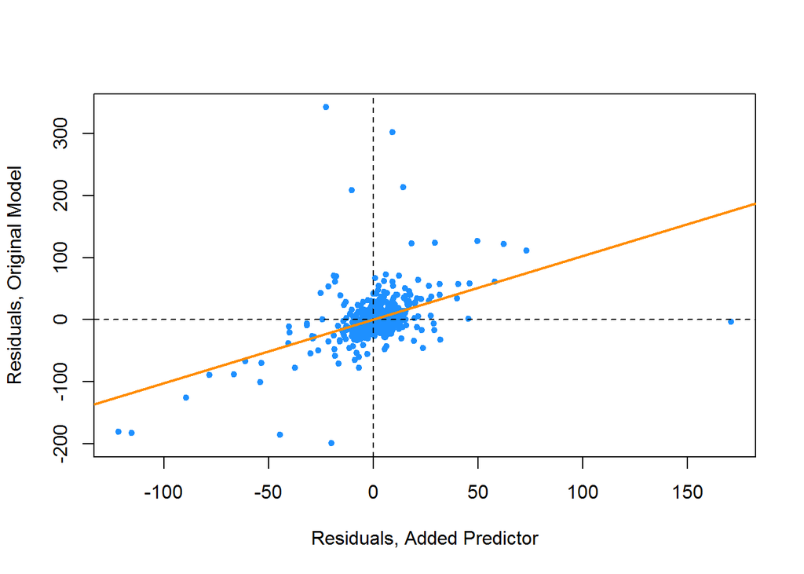

```r
#variable added plot
plot(resid(model_small) ~ resid(x11_model_small), col = "dodgerblue", pch = 20,
     xlab = "Residuals, Added Predictor", ylab = "Residuals, Original Model")
abline(h = 0, lty = 2)
abline(v = 0, lty = 2)
abline(lm(resid(model_small) ~ resid(x11_model_small)),
       col = "darkorange", lwd = 2)
```

#### Interactions Analysis

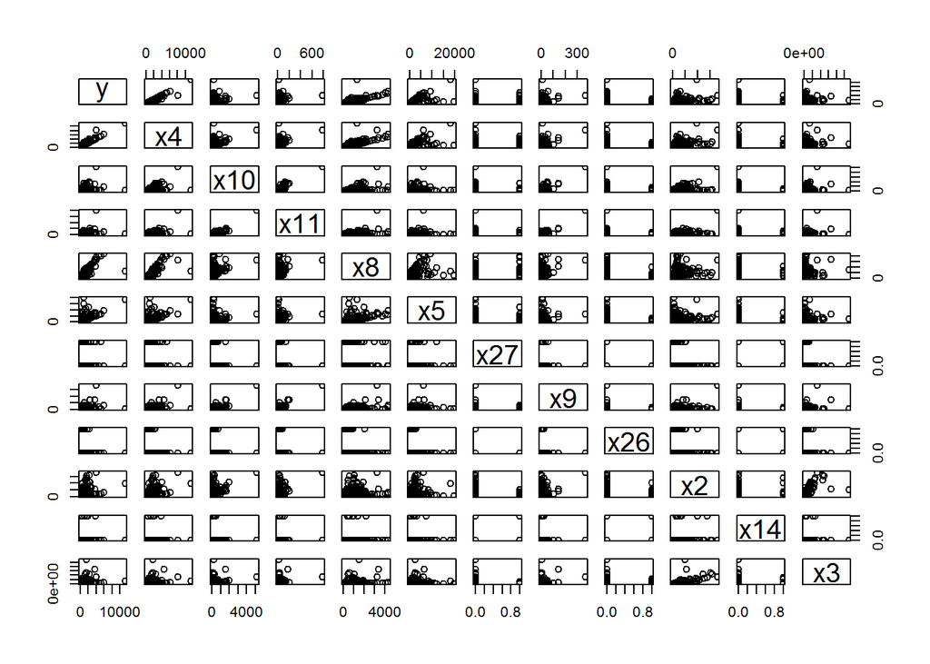

```r
###############################################################################
#next will examine interaction terms
#x4, x10, x11, x8, x5, x27, x9, x26, x2, x14, x3
################################################################################
fb_limited = data.frame(
  y   = new_data$y,
  x4  = new_data$x4,
  x10 = new_data$x10,
  x11 = new_data$x11,
  x8 = new_data$x8,
  x5 = new_data$x5,
  x27 = new_data$x27,
  x9 = new_data$x9,
  x26 = new_data$x26,
  x2 = new_data$x2,
  x14 = new_data$x14,
  x3 = new_data$x3)

pairs(fb_limited)
```

```r
model_interact = lm(y ~ (x4 + x10 + x11 + x8 + x5 + x27 + x9 + x26 + x2 + x14 + x3) ^ 2, data = fb_limited)
summary(model_interact)
```

```
##
## Call:
## lm(formula = y ~ (x4 + x10 + x11 + x8 + x5 + x27 + x9 + x26 +
##     x2 + x14 + x3)^2, data = fb_limited)
##
## Residuals:
##     Min      1Q  Median      3Q     Max
## -72.482  -6.091  -0.188   5.519  81.781
##
## Coefficients: (5 not defined because of singularities)
##               Estimate Std. Error t value Pr(>|t|)
## (Intercept)  1.220e+00  2.150e+00   0.568 0.570536
## x4           1.006e+00  6.481e-03 155.300  < 2e-16 ***
## x10         -9.143e-01  2.151e-02 -42.503  < 2e-16 ***
## x11          1.030e+00  1.197e-01   8.608  < 2e-16 ***
## x8           1.368e-02  8.680e-03   1.577 0.115629
## x5          -2.906e-03  1.500e-03  -1.937 0.053376 .
## x27         -9.421e+00  4.469e+00  -2.108 0.035589 *
## x9           4.774e-01  1.946e-01   2.454 0.014533 *
## x26         -4.770e+00  5.023e+00  -0.950 0.342855
## x2           5.273e-04  2.572e-04   2.050 0.040929 *
## x14         -4.579e+01  5.264e+01  -0.870 0.384797
## x3          -4.788e-04  1.266e-04  -3.783 0.000177 ***
## x4:x10       1.458e-04  3.894e-05   3.743 0.000206 ***
## x4:x11      -5.243e-04  3.054e-04  -1.717 0.086735 .
## x4:x8       -3.357e-06  2.890e-06  -1.161 0.246097
## x4:x5        7.840e-07  9.323e-07   0.841 0.400891
## x4:x27      -2.446e-02  2.219e-02  -1.102 0.271052
## x4:x9        4.927e-04  5.279e-04   0.933 0.351133
## x4:x26       1.192e-01  9.493e-02   1.256 0.209756
## x4:x2       -9.608e-07  3.871e-07  -2.482 0.013454 *
## x4:x14      -4.754e-02  1.036e-01  -0.459 0.646389
## x4:x3        8.865e-08  1.269e-07   0.698 0.485256
## x10:x11     -9.651e-04  2.574e-04  -3.749 0.000202 ***
## x10:x8      -1.361e-04  4.073e-05  -3.342 0.000904 ***
## x10:x5       4.742e-05  7.114e-06   6.666 8.03e-11 ***
## x10:x27     -1.523e-02  3.489e-02  -0.436 0.662696
## x10:x9       2.046e-04  5.575e-04   0.367 0.713832
## x10:x26      2.999e-02  6.517e-02   0.460 0.645676
## x10:x2      -3.400e-06  1.298e-06  -2.618 0.009143 **
```

[output cut: 29 more lines]

```
## x9:x2       -1.661e-05  1.250e-05  -1.329 0.184664
## x9:x14              NA         NA      NA       NA
## x9:x3       -1.041e-05  2.708e-06  -3.845 0.000138 ***
## x26:x2      -1.411e-03  1.244e-03  -1.134 0.257287
## x26:x14             NA         NA      NA       NA
## x26:x3       5.591e-04  3.342e-04   1.673 0.095131 .
## x2:x14              NA         NA      NA       NA
## x2:x3        3.354e-09  7.768e-10   4.318 1.95e-05 ***
## x14:x3              NA         NA      NA       NA
## ---
## Signif. codes:  0 '***' 0.001 '**' 0.01 '*' 0.05 '.' 0.1 ' ' 1
##
## Residual standard error: 14.95 on 433 degrees of freedom
## Multiple R-squared:  0.9997, Adjusted R-squared:  0.9997
## F-statistic: 2.838e+04 on 61 and 433 DF,  p-value: < 2.2e-16
```

```r
anova(model_add_selected, model_interact)
```

```
## Analysis of Variance Table
##
## Model 1: y ~ x4 + x10 + x11 + x8 + x5 + x27 + x9 + x26 + x2 + x14 + x3
## Model 2: y ~ (x4 + x10 + x11 + x8 + x5 + x27 + x9 + x26 + x2 + x14 + x3)^2
##   Res.Df    RSS Df Sum of Sq      F    Pr(>F)
## 1    483 456003
## 2    433  96794 50    359210 32.138 < 2.2e-16 ***
## ---
## Signif. codes:  0 '***' 0.001 '**' 0.01 '*' 0.05 '.' 0.1 ' ' 1
```

```r
#above shows some interaction is good. - the overal p value is showing that some interaction is significant


#look at AIC and BIC and adjusted R^2 to help determine which interactions we should explore
#AIC seems to agree
model_back_aic = step(model_interact, direction = "backward", trace = 0)
summary(model_back_aic)
```

```
##
## Call:
## lm(formula = y ~ x4 + x10 + x11 + x8 + x5 + x27 + x9 + x26 +
##     x2 + x14 + x3 + x4:x10 + x4:x11 + x4:x8 + x4:x5 + x4:x27 +
##     x4:x26 + x4:x2 + x4:x14 + x10:x11 + x10:x8 + x10:x5 + x10:x2 +
##     x11:x8 + x11:x27 + x11:x9 + x11:x26 + x11:x14 + x11:x3 +
##     x8:x26 + x8:x14 + x8:x3 + x5:x9 + x5:x2 + x5:x3 + x27:x2 +
##     x27:x14 + x9:x3 + x26:x2 + x26:x3 + x2:x3, data = fb_limited)
##
## Residuals:
##     Min      1Q  Median      3Q     Max
## -74.635  -5.924  -0.465   5.758  79.181
##
## Coefficients:
##               Estimate Std. Error t value Pr(>|t|)
## (Intercept)  1.505e+00  1.906e+00   0.789 0.430271
## x4           1.004e+00  5.467e-03 183.712  < 2e-16 ***
## x10         -9.136e-01  1.759e-02 -51.940  < 2e-16 ***
## x11          1.051e+00  1.060e-01   9.911  < 2e-16 ***
## x8           1.441e-02  6.893e-03   2.090 0.037188 *
## x5          -3.031e-03  1.212e-03  -2.501 0.012741 *
## x27         -8.229e+00  3.583e+00  -2.297 0.022093 *
## x9           4.311e-01  1.343e-01   3.211 0.001416 **
## x26         -5.514e+00  4.601e+00  -1.198 0.231359
## x2           5.798e-04  1.981e-04   2.927 0.003592 **
## x14         -3.203e+00  1.445e+01  -0.222 0.824752
## x3          -5.069e-04  1.066e-04  -4.754 2.69e-06 ***
## x4:x10       1.446e-04  2.279e-05   6.345 5.40e-10 ***
## x4:x11      -3.454e-04  1.428e-04  -2.419 0.015946 *
## x4:x8       -5.392e-06  1.442e-06  -3.738 0.000209 ***
## x4:x5        1.049e-06  5.178e-07   2.026 0.043379 *
## x4:x27      -7.265e-03  3.070e-03  -2.366 0.018383 *
## x4:x26       1.430e-01  6.690e-02   2.138 0.033059 *
## x4:x2       -6.565e-07  1.821e-07  -3.606 0.000346 ***
## x4:x14      -9.965e-02  3.682e-02  -2.706 0.007061 **
## x10:x11     -9.372e-04  1.823e-04  -5.141 4.07e-07 ***
## x10:x8      -1.296e-04  2.627e-05  -4.933 1.14e-06 ***
## x10:x5       4.651e-05  5.505e-06   8.449 4.04e-16 ***
## x10:x2      -3.262e-06  4.005e-07  -8.145 3.72e-15 ***
## x11:x8       4.339e-04  1.812e-04   2.395 0.017030 *
```

[output cut: 8 more lines]

```
## x5:x9       -8.120e-05  4.693e-05  -1.730 0.084256 .
## x5:x2        2.242e-07  1.239e-07   1.809 0.071126 .
## x5:x3       -8.060e-08  4.507e-08  -1.788 0.074368 .
## x27:x2       8.519e-04  3.000e-04   2.840 0.004717 **
## x27:x14      4.765e+01  2.200e+01   2.166 0.030845 *
## x9:x3       -1.243e-05  1.715e-06  -7.244 1.89e-12 ***
## x26:x2      -1.699e-03  1.147e-03  -1.481 0.139314
## x26:x3       6.290e-04  3.142e-04   2.002 0.045915 *
## x2:x3        3.304e-09  6.344e-10   5.208 2.90e-07 ***
## ---
## Signif. codes:  0 '***' 0.001 '**' 0.01 '*' 0.05 '.' 0.1 ' ' 1
##
## Residual standard error: 14.76 on 453 degrees of freedom
## Multiple R-squared:  0.9997, Adjusted R-squared:  0.9997
## F-statistic: 4.335e+04 on 41 and 453 DF,  p-value: < 2.2e-16
```

```r
car::vif(model_back_aic)
```

```
##          x4         x10         x11          x8          x5         x27
##   66.144744   73.878850   46.414442   40.685986   13.436707    2.650604
##          x9         x26          x2         x14          x3      x4:x10
##   18.507526    3.977070   46.351616    6.622244  153.504036 4751.470173
##      x4:x11       x4:x8       x4:x5      x4:x27      x4:x26       x4:x2
## 4029.568320   37.707190   69.783662    4.222014  433.442441  673.362072
##      x4:x14     x10:x11      x10:x8      x10:x5      x10:x2      x11:x8
##  176.774238 2598.897663 1265.524285  197.700911  721.962620 1210.515661
##     x11:x27      x11:x9     x11:x26     x11:x14      x11:x3      x8:x26
##    4.096464 1516.100830    6.532529    9.024752  466.868200  239.723189
##      x8:x14       x8:x3       x5:x9       x5:x2       x5:x3      x27:x2
##  208.376905  307.673011   75.406718  459.110699  426.630863    4.344903
##     x27:x14       x9:x3      x26:x2      x26:x3       x2:x3
##    2.218907  321.287410  142.004200   58.111551   49.036849
```

```r
#BIC check
n = length(resid(model_interact))
model_back_bic = step(model_interact, direction = "backward", k = log(n), trace = 0)
summary(model_back_bic)
```

```
##
## Call:
## lm(formula = y ~ x4 + x10 + x11 + x8 + x5 + x27 + x9 + x26 +
##     x2 + x3 + x4:x10 + x4:x8 + x4:x2 + x10:x11 + x10:x8 + x10:x5 +
##     x10:x2 + x11:x27 + x11:x9 + x11:x26 + x11:x3 + x8:x3 + x27:x2 +
##     x9:x3 + x26:x3 + x2:x3, data = fb_limited)
##
## Residuals:
##     Min      1Q  Median      3Q     Max
## -75.990  -6.869  -0.689   6.010  83.603
##
## Coefficients:
##               Estimate Std. Error t value Pr(>|t|)
## (Intercept)  1.336e+00  1.740e+00   0.768 0.442943
## x4           9.976e-01  4.635e-03 215.259  < 2e-16 ***
## x10         -9.167e-01  1.388e-02 -66.060  < 2e-16 ***
## x11          1.045e+00  7.305e-02  14.307  < 2e-16 ***
## x8           2.179e-02  5.819e-03   3.745 0.000203 ***
## x5          -2.467e-03  8.810e-04  -2.800 0.005321 **
## x27         -8.728e+00  3.550e+00  -2.459 0.014306 *
## x9           4.235e-01  1.137e-01   3.723 0.000221 ***
## x26         -2.535e+00  3.864e+00  -0.656 0.512035
## x2           4.613e-04  1.203e-04   3.833 0.000144 ***
## x3          -3.501e-04  7.702e-05  -4.546 6.98e-06 ***
## x4:x10       1.062e-04  1.713e-05   6.199 1.25e-09 ***
## x4:x8       -5.606e-06  1.067e-06  -5.252 2.29e-07 ***
## x4:x2       -1.921e-07  4.265e-08  -4.505 8.39e-06 ***
## x10:x11     -7.057e-04  1.589e-04  -4.441 1.12e-05 ***
## x10:x8      -7.843e-05  1.764e-05  -4.446 1.09e-05 ***
## x10:x5       4.748e-05  4.689e-06  10.126  < 2e-16 ***
## x10:x2      -3.516e-06  3.433e-07 -10.242  < 2e-16 ***
## x11:x27     -7.146e-01  1.258e-01  -5.681 2.36e-08 ***
## x11:x9       4.655e-03  1.745e-03   2.668 0.007895 **
## x11:x26     -7.865e-01  1.258e-01  -6.252 9.13e-10 ***
## x11:x3       4.690e-06  9.525e-07   4.924 1.18e-06 ***
## x8:x3        1.728e-07  4.554e-08   3.795 0.000167 ***
## x27:x2       7.586e-04  2.423e-04   3.131 0.001850 **
## x9:x3       -9.925e-06  1.296e-06  -7.656 1.11e-13 ***
## x26:x3       2.006e-04  6.426e-05   3.121 0.001912 **
## x2:x3        1.840e-09  3.729e-10   4.934 1.12e-06 ***
## ---
## Signif. codes:  0 '***' 0.001 '**' 0.01 '*' 0.05 '.' 0.1 ' ' 1
##
## Residual standard error: 15.08 on 468 degrees of freedom
## Multiple R-squared:  0.9997, Adjusted R-squared:  0.9997
## F-statistic: 6.545e+04 on 26 and 468 DF,  p-value: < 2.2e-16
```

```r
#comparing VIF found in origianl model and BIC backward
car::vif(model_add_selected)
```

```
##       x4      x10      x11       x8       x5      x27       x9      x26
## 5.961024 7.149901 7.606162 3.727893 2.039644 1.034436 4.568778 1.062747
##       x2      x14       x3
## 3.125982 1.109636 2.061436
```

```r
car::vif(model_back_aic)
```

```
##          x4         x10         x11          x8          x5         x27
##   66.144744   73.878850   46.414442   40.685986   13.436707    2.650604
##          x9         x26          x2         x14          x3      x4:x10
##   18.507526    3.977070   46.351616    6.622244  153.504036 4751.470173
##      x4:x11       x4:x8       x4:x5      x4:x27      x4:x26       x4:x2
## 4029.568320   37.707190   69.783662    4.222014  433.442441  673.362072
##      x4:x14     x10:x11      x10:x8      x10:x5      x10:x2      x11:x8
##  176.774238 2598.897663 1265.524285  197.700911  721.962620 1210.515661
##     x11:x27      x11:x9     x11:x26     x11:x14      x11:x3      x8:x26
##    4.096464 1516.100830    6.532529    9.024752  466.868200  239.723189
##      x8:x14       x8:x3       x5:x9       x5:x2       x5:x3      x27:x2
##  208.376905  307.673011   75.406718  459.110699  426.630863    4.344903
##     x27:x14       x9:x3      x26:x2      x26:x3       x2:x3
##    2.218907  321.287410  142.004200   58.111551   49.036849
```

```r
car::vif(model_back_bic)
```

```
##          x4         x10         x11          x8          x5         x27
##   45.519181   44.024710   21.093009   27.756168    6.795436    2.490485
##          x9         x26          x2          x3      x4:x10       x4:x8
##   12.717859    2.685363   16.383311   76.681586 2570.645755   19.771668
##       x4:x2     x10:x11      x10:x8      x10:x5      x10:x2     x11:x27
##   35.383433 1890.568598  546.249322  137.316772  507.952214    3.431311
##      x11:x9     x11:x26      x11:x3       x8:x3      x27:x2       x9:x3
## 1175.959130    3.173615  321.213585   93.026682    2.713071  175.707757
##      x26:x3       x2:x3
##    2.327050   16.222998
```

```r
#since that did reduced the VIF of x4, we will proceed with removing x17

#Given the high VIF that was introducted, we can see that x27 interactions do not appear to introduce
#high VIF
model_interact = lm(y ~ (x4 + x10 + x11 + x8 + x5 + x27 + x9 + x26 + x2 + x14 + x3)* x27, data = fb_limited)

summary(model_interact)
```

```
##
## Call:
## lm(formula = y ~ (x4 + x10 + x11 + x8 + x5 + x27 + x9 + x26 +
##     x2 + x14 + x3) * x27, data = fb_limited)
##
## Residuals:
##      Min       1Q   Median       3Q      Max
## -167.082   -9.596   -1.501    9.278  287.838
##
## Coefficients: (1 not defined because of singularities)
##               Estimate Std. Error t value Pr(>|t|)
## (Intercept) -4.450e-01  2.386e+00  -0.186  0.85214
## x4           9.977e-01  3.356e-03 297.313  < 2e-16 ***
## x10         -9.239e-01  1.168e-02 -79.124  < 2e-16 ***
## x11          8.446e-01  9.005e-02   9.379  < 2e-16 ***
## x8           3.391e-02  4.492e-03   7.549 2.27e-13 ***
## x5           5.673e-03  9.939e-04   5.708 2.02e-08 ***
## x27         -1.719e+00  8.190e+00  -0.210  0.83382
## x9           4.462e-01  1.384e-01   3.223  0.00136 **
## x26         -1.911e+01  4.819e+00  -3.965 8.46e-05 ***
## x2          -5.416e-04  1.040e-04  -5.209 2.84e-07 ***
## x14          2.775e+01  1.297e+01   2.140  0.03287 *
## x3           6.049e-05  2.494e-05   2.426  0.01564 *
## x4:x27       4.325e-02  3.990e-02   1.084  0.27903
## x10:x27     -8.548e-02  6.284e-02  -1.360  0.17435
## x11:x27     -1.162e-01  5.083e-01  -0.229  0.81928
## x8:x27      -6.981e-02  4.888e-02  -1.428  0.15385
## x5:x27      -5.814e-03  3.673e-03  -1.583  0.11404
## x27:x9      -2.175e-02  7.009e-01  -0.031  0.97525
## x27:x26             NA         NA      NA       NA
## x27:x2      -1.125e-03  3.738e-03  -0.301  0.76350
## x27:x14     -7.242e+00  4.588e+01  -0.158  0.87465
## x27:x3       1.079e-03  1.859e-03   0.581  0.56171
## ---
## Signif. codes:  0 '***' 0.001 '**' 0.01 '*' 0.05 '.' 0.1 ' ' 1
##
## Residual standard error: 29.71 on 474 degrees of freedom
## Multiple R-squared:  0.9989, Adjusted R-squared:  0.9989
## F-statistic: 2.191e+04 on 20 and 474 DF,  p-value: < 2.2e-16
```

```r
#some of the interactiosn are significant
anova(model_add_selected, model_interact)
```

```
## Analysis of Variance Table
##
## Model 1: y ~ x4 + x10 + x11 + x8 + x5 + x27 + x9 + x26 + x2 + x14 + x3
## Model 2: y ~ (x4 + x10 + x11 + x8 + x5 + x27 + x9 + x26 + x2 + x14 + x3) *
##     x27
##   Res.Df    RSS Df Sum of Sq      F    Pr(>F)
## 1    483 456003
## 2    474 418262  9     37741 4.7523 4.506e-06 ***
## ---
## Signif. codes:  0 '***' 0.001 '**' 0.01 '*' 0.05 '.' 0.1 ' ' 1
```

```r
n = length(resid(model_interact))
model_back_bic = step(model_interact, direction = "backward", k = log(n), trace = 0)
summary(model_back_bic)
```

```
##
## Call:
## lm(formula = y ~ x4 + x10 + x11 + x8 + x5 + x27 + x9 + x26 +
##     x2 + x14 + x10:x27 + x5:x27, data = fb_limited)
##
## Residuals:
##      Min       1Q   Median       3Q      Max
## -172.646  -10.013   -2.038    9.244  290.407
##
## Coefficients:
##               Estimate Std. Error t value Pr(>|t|)
## (Intercept)  2.709e-01  2.332e+00   0.116 0.907564
## x4           9.960e-01  3.285e-03 303.227  < 2e-16 ***
## x10         -9.234e-01  1.144e-02 -80.682  < 2e-16 ***
## x11          8.110e-01  8.756e-02   9.262  < 2e-16 ***
## x8           3.408e-02  4.288e-03   7.946 1.37e-14 ***
## x5           5.963e-03  9.712e-04   6.141 1.72e-09 ***
## x27         -3.901e+00  5.973e+00  -0.653 0.514001
## x9           5.229e-01  1.341e-01   3.900 0.000110 ***
## x26         -1.964e+01  4.822e+00  -4.072 5.44e-05 ***
## x2          -3.727e-04  8.043e-05  -4.634 4.62e-06 ***
## x14          3.236e+01  1.196e+01   2.706 0.007057 **
## x10:x27     -6.453e-02  1.813e-02  -3.559 0.000409 ***
## x5:x27      -1.081e-02  2.304e-03  -4.691 3.54e-06 ***
## ---
## Signif. codes:  0 '***' 0.001 '**' 0.01 '*' 0.05 '.' 0.1 ' ' 1
##
## Residual standard error: 29.84 on 482 degrees of freedom
## Multiple R-squared:  0.9989, Adjusted R-squared:  0.9989
## F-statistic: 3.617e+04 on 12 and 482 DF,  p-value: < 2.2e-16
```

```r
#did not significantly raise
car::vif(model_back_bic)
```

```
##       x4      x10      x11       x8       x5      x27       x9      x26
## 5.837952 7.645468 7.737463 3.849222 2.108336 1.800620 4.511913 1.067834
##       x2      x14  x10:x27   x5:x27
## 1.868489 1.108380 1.606379 1.613671
```

```r
car::vif(model_add_selected)
```

```
##       x4      x10      x11       x8       x5      x27       x9      x26
## 5.961024 7.149901 7.606162 3.727893 2.039644 1.034436 4.568778 1.062747
##       x2      x14       x3
## 3.125982 1.109636 2.061436
```

```r
anova(model_add_selected, model_back_bic)
```

```
## Analysis of Variance Table
##
## Model 1: y ~ x4 + x10 + x11 + x8 + x5 + x27 + x9 + x26 + x2 + x14 + x3
## Model 2: y ~ x4 + x10 + x11 + x8 + x5 + x27 + x9 + x26 + x2 + x14 + x10:x27 +
##     x5:x27
##   Res.Df    RSS Df Sum of Sq     F    Pr(>F)
## 1    483 456003
## 2    482 429327  1     26677 29.95 7.141e-08 ***
## ---
## Signif. codes:  0 '***' 0.001 '**' 0.01 '*' 0.05 '.' 0.1 ' ' 1
```